# ONAM data examples

Code to reproduce results from Köhler, Rügamer and Schmid (2024):

https://arxiv.org/abs/2407.18650

For an updated version of the ONAM package, see

https://github.com/Koehlibert/ONAM_R

## Install package:

```r
install.packages("devtools")
library(devtools)
devtools::install_github("Koehlibert/ONAM")
```

If this is the first time using keras or tensorflow in R, you need to run `keras::install_keras()`.

# Random forest for Chesapeake Bay watershed biotic integrity prediction

Load data and setup model architecture

```r
library(keras)
library(dplyr)
library(readxl)
library(ONAM)
#load data
trainData <- read_xlsx("BIBITrain.xlsx")
head(trainData)
```

```
## # A tibble: 6 × 20
##   Latitude Longitude BioregUpstream2 AreaSqKM dep_so4_2011 elevation
##      <dbl>     <dbl>           <dbl>    <dbl>        <dbl>     <dbl>
## 1     39.4     -79.0              11     3.22        12.5       467.
## 2     40.1     -78.7               7     1.95        12.0       450.
## 3     41.8     -77.7               6   116.          13.3       664.
## 4     39.7     -78.4              11   133.          10.9       335.
## 5     38.6     -77.9               3    65.5          8.53      165.
## 6     40.1     -75.9              12    53.1         14.3       207.
## # ℹ 14 more variables: hydrogroup_d4 <dbl>, percent_sandy <dbl>,
## #   surfcoarse <dbl>, deg_barr_all_local <dbl>, upstream.total_precip <dbl>,
## #   Agriculture <dbl>, Development <dbl>, Forest <dbl>, Openwater <dbl>,
## #   Barren <dbl>, Grass <dbl>, Woodywetland <dbl>, Herbwetland <dbl>,
## #   Prediction <dbl>
```

```r
#define model formula
BIBI_formula <-
  Prediction ~ mod(Latitude) + mod(Longitude) +
  mod(BioregUpstream2) + mod(AreaSqKM) +
  mod(dep_so4_2011) + mod(elevation) +
  mod(hydrogroup_d4) + mod(percent_sandy) +
  mod(surfcoarse) + mod(deg_barr_all_local) +
  mod(upstream.total_precip) + mod(Agriculture) +
  mod(Development) + mod(Forest) + mod(Openwater) +
  mod(Barren) + mod(Grass) + mod(Woodywetland) +
  mod(Herbwetland) +
  mod(Development, elevation) +
  mod(Agriculture, elevation) +
  mod(Agriculture, Development) +
  mod(.)
#Specify model architecture in a named list where the name corresponds to the model name in the model formula
list_of_mods_BIBI <- list(mod = ONAM:::get_submodel)
categorical_features <- c("BioregUpstream2")
#Fit PHONAM model
trainData <- as.matrix(trainData)
BIBIExpl <-
  onam(
    BIBI_formula,
    list_of_mods_BIBI,
    categorical_features = categorical_features,
    trainData,
    n_ensemble = 4,
    epochs = 500,
    progresstext = FALSE,
    verbose = 0
  )
#generate prediction object for saving
BIBI_Res <- predict(BIBIExpl)
saveRDS(BIBI_Res, "BIBI_Res.RDS")
```

## Model visualization

```r
summary(BIBIExpl)
```

```
##
## Call:
## onam(formula = BIBI_formula, list_of_deep_models = list_of_mods_BIBI,
##     data = trainData, categorical_features = categorical_features,
##     n_ensemble = 4, epochs = 500, progresstext = FALSE, verbose = 0)
##
## Correlation of model prediction with outcome variable: 0.9824
## Number of ensemble members:  4
## I_1: 0.7928; I_2:  0.0209
## Degree of interpretability: 0.8137
```

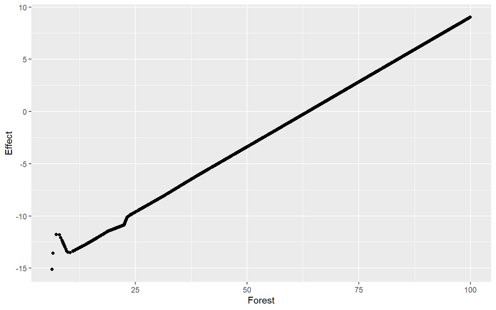

```r
BIBI_res <- readRDS("BIBI_Res.RDS")

plot_main_effect(BIBI_Res, "Forest")
```

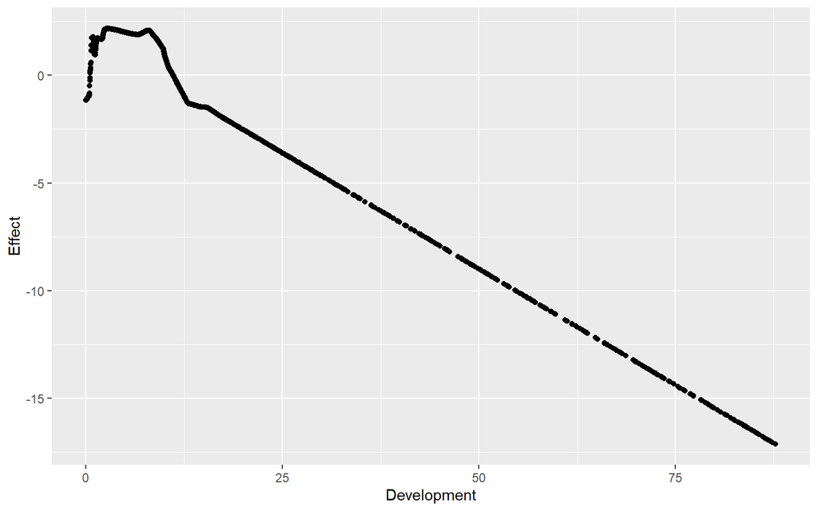

```r
plot_main_effect(BIBI_Res, "Development")
```

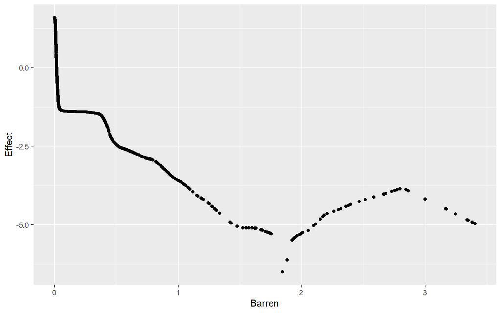

```r
plot_main_effect(BIBI_Res, "Barren")
```

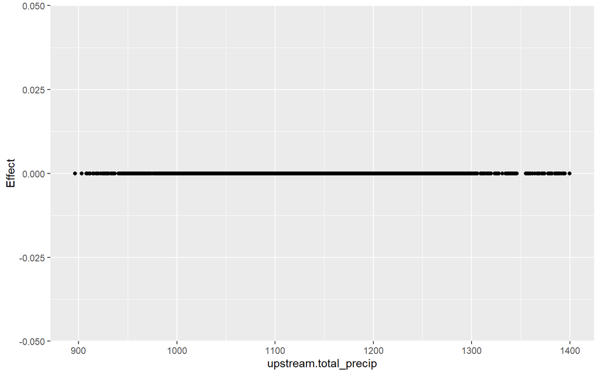

```r
plot_main_effect(BIBI_Res, "upstream.total_precip")
```

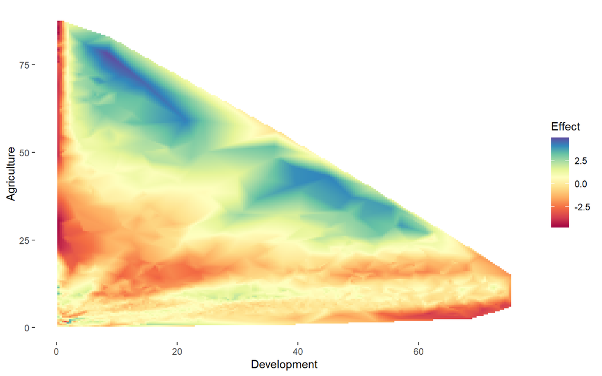

```r
plot_inter_effect(BIBI_Res, "Development", "Agriculture", interpolate = TRUE)
```

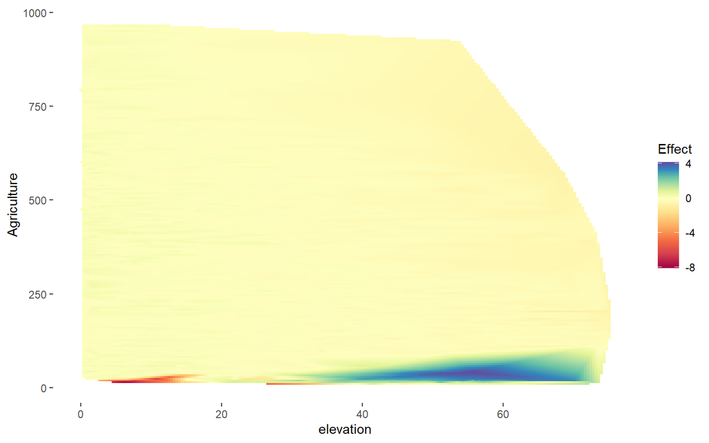

```r
plot_inter_effect(BIBI_Res, "Agriculture", "elevation", interpolate = TRUE)
```

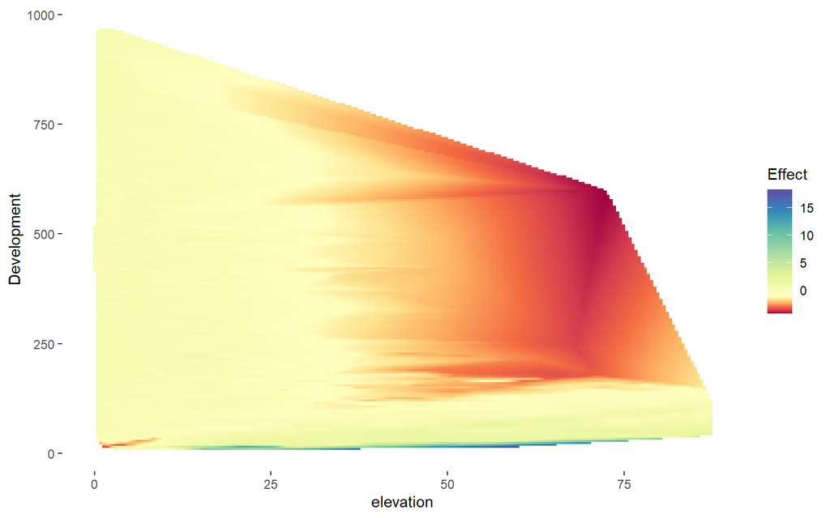

```r
plot_inter_effect(BIBI_Res, "Development", "elevation", interpolate = TRUE)
```

# Binary classification support vector machine for diabetes prediction

The Pima Indians Diabetes Database is a dataset from the Indian National Institute of Diabetes and Digestive and Kidney Dieseases. https://www.mdpi.com/2076-3417/9/21/4604

```r
library(mlbench)
library(e1071)
library(caret)
data(PimaIndiansDiabetes)
diabetes_data <- PimaIndiansDiabetes %>%
  mutate(diabetes = as.factor(ifelse(diabetes == "pos", 1, 0))) %>%
  mutate(across(!diabetes, as.numeric))

head(diabetes_data)
```

```
##   pregnant glucose pressure triceps insulin mass pedigree age diabetes
## 1        6     148       72      35       0 33.6    0.627  50        1
## 2        1      85       66      29       0 26.6    0.351  31        0
## 3        8     183       64       0       0 23.3    0.672  32        1
## 4        1      89       66      23      94 28.1    0.167  21        0
## 5        0     137       40      35     168 43.1    2.288  33        1
## 6        5     116       74       0       0 25.6    0.201  30        0
```

It consists of 768 instances of multiple medical features and the diabetes status of each observation. There are 268 diabetes cases and 500 controls in the dataset.

We demonstrate how to use ONAM to explain the prediction of a support vector machine for prediction of the diabetes status.

First, we fit a support vector machine with radial kernel. Hyperparameters are selected using grid search.

```r
# Define a grid of parameters to search
tune_grid <- expand.grid(C = c(0.1, 1, 10), sigma = c(0.5, 1))

# Train the model using cross-validation
svm_tuned <- train(diabetes ~ ., data = diabetes_data,
                   method = "svmRadial",
                   trControl = trainControl(method = "cv", number = 10),
                   tuneGrid = tune_grid)
svm_best_params <- svm_tuned$bestTune
svm_mod <- svm(diabetes ~ ., data = diabetes_data, kernel = "radial",
               cost = svm_best_params$C,
               sigma = svm_best_params$sigma)
svm_accuracy <-
  sum(predict(svm_mod, diabetes_data) ==
        diabetes_data$diabetes)/nrow(diabetes_data)
summary(svm_mod)
```

```
##
## Call:
## svm(formula = diabetes ~ ., data = diabetes_data, kernel = "radial",
##     cost = svm_best_params$C, sigma = svm_best_params$sigma)
##
##
## Parameters:
##    SVM-Type:  C-classification
##  SVM-Kernel:  radial
##        cost:  1
##
## Number of Support Vectors:  435
##
##  ( 212 223 )
##
##
## Number of Classes:  2
##
## Levels:
##  0 1
```

Model accuracy: 0.8242

## Fit ONAM model on svm data

We explain the svm using the orthogonal additive model framework for binary classification:

```r
Diabetes_formula <- diabetes ~ mod(glucose) + mod(insulin) +
  mod(pregnant) + mod(pressure) + mod(triceps) + mod(pedigree) +
  mod(mass) + mod(age) + mod(glucose, insulin) + mod(age, mass) +
  mod(.)
list_of_mods_Diabetes <- list(mod = ONAM:::get_submodel)
svm_expl <- onam(Diabetes_formula, list_of_mods_Diabetes,
                 diabetes_data, svm_mod, target = "binary", n_ensemble = 4,
                 epochs = 500, verbose = 0)
# summary(svm_expl)

#generate prediction object for saving
svm_res <- predict(svm_expl)
saveRDS(svm_res, "svm_res.RDS")
```

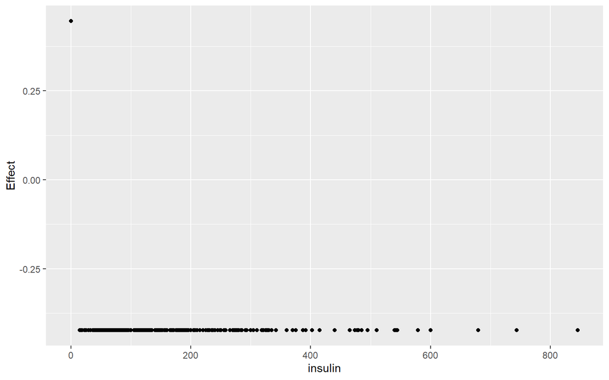

```r
svm_res <- readRDS("svm_res.RDS")

plot_main_effect(svm_res, "insulin")
```

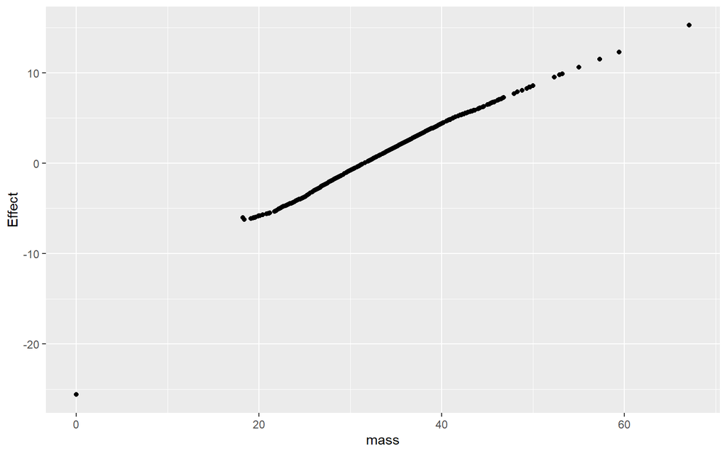

```r
plot_main_effect(svm_res, "mass")
```

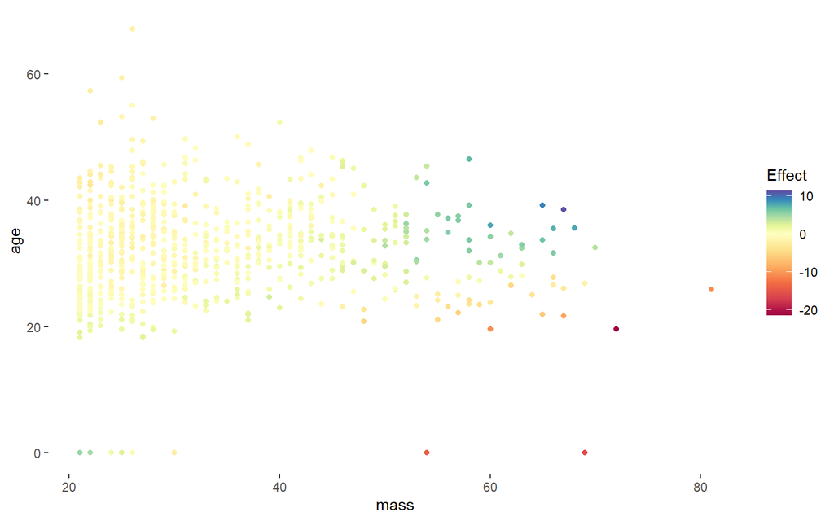

```r
plot_inter_effect(svm_res, "age", "mass", interpolate = FALSE)
```

# Binary classification of insurance claims using xgboost

The dataCar dataset from the insuranceData-package contains data on one-year vehicle insurance policies taken out in 2004 and 2005.

```r
library(insuranceData)
library(xgboost)
library(dplyr)
library(caret)
data("dataCar")
dataCar_subset <- dataCar %>%
  select(veh_value, veh_body, veh_age, gender, area, agecat, clm) %>%
  mutate_all(as.numeric)

head(dataCar_subset)
```

```
##   veh_value veh_body veh_age gender area agecat clm
## 1      1.06        4       3      1    3      2   0
## 2      1.03        4       2      1    1      4   0
## 3      3.26       13       2      1    5      2   0
## 4      4.14       11       2      1    4      2   0
## 5      0.72        4       4      1    3      2   0
## 6      2.01        5       3      2    3      4   0
```

The dataset contains 67856 policies, 4624 of which had at least one insurance claim. We use xgboost to fit a binary prediction model to predict if an insurance claim is made.

```r
dataCar_train <- dataCar_subset[sample(1:nrow(dataCar_subset), 10000),]

train_insurance <- dataCar_train %>% select(-clm)
label_insurance <- dataCar_train %>% select(clm) %>% unlist()

xgb_train_insurance <- xgb.DMatrix(as.matrix(train_insurance),
                                   label = label_insurance)

xgb_mod <- xgboost(xgb_train_insurance, nrounds = 10000, verbose = 0,
                   # print_every_n = 100,
                   objective = "binary:logistic",
                   eval_metric = "logloss")
summary(xgb_mod)
```

```
##                Length   Class              Mode
## handle                1 xgb.Booster.handle externalptr
## raw            19628397 -none-             raw
## niter                 1 -none-             numeric
## evaluation_log        2 data.table         list
## call                 15 -none-             call
## params                3 -none-             list
## callbacks             1 -none-             list
## feature_names         6 -none-             character
## nfeatures             1 -none-             numeric
```

```r
preds <- as.numeric(predict(xgb_mod, xgb_train_insurance) > 0.5)

confusionMatrix(as.factor(preds), as.factor(unlist(label_insurance)))
```

```
## Confusion Matrix and Statistics
##
##           Reference
## Prediction    0    1
##          0 9328   96
##          1    6  570
##
##                Accuracy : 0.9898
##                  95% CI : (0.9876, 0.9917)
##     No Information Rate : 0.9334
##     P-Value [Acc > NIR] : < 2.2e-16
##
##                   Kappa : 0.9125
##
##  Mcnemar's Test P-Value : < 2.2e-16
##
##             Sensitivity : 0.9994
##             Specificity : 0.8559
##          Pos Pred Value : 0.9898
##          Neg Pred Value : 0.9896
##              Prevalence : 0.9334
##          Detection Rate : 0.9328
##    Detection Prevalence : 0.9424
##       Balanced Accuracy : 0.9276
##
##        'Positive' Class : 0
##
```

## Fit ONAM model on xgboost data

We explain the xgboost using the orthogonal additive model framework for binary classification:

```r
Insurance_formula <- clm ~ mod(veh_value) + mod(veh_body) + mod(veh_age) +
  mod(gender) + mod(area) + mod(agecat) + mod(veh_age, veh_value) +
  mod(.)

list_of_deep_models_Insurance <- list(mod = ONAM:::get_submodel)

categorical_features <- c("veh_body", "agecat", "area", "gender")

xgb_expl <-
  onam(
    Insurance_formula,
    list_of_deep_models_Insurance,
    train_insurance,
    target = "binary",
    model = xgb_mod,
    model_data = xgb_train_insurance,
    categorical_features = categorical_features,
    n_ensemble = 4,
    epochs = 500,
    verbose = 0
  )

xgb_res <- predict(xgb_expl)
saveRDS(xgb_res, "xgb_res.RDS")
```

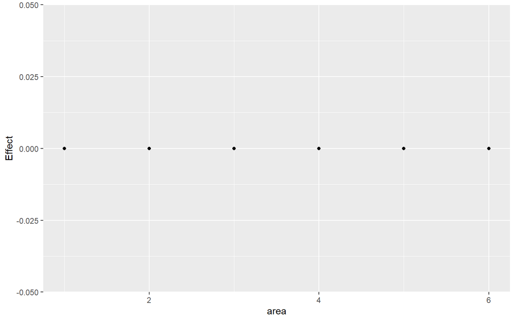

```r
xgb_res <- readRDS("xgb_res.RDS")

plot_main_effect(xgb_expl, "area")
```

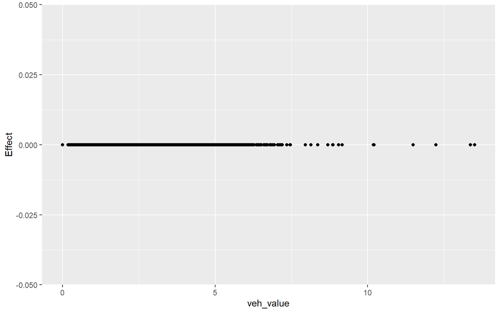

```r
plot_main_effect(xgb_expl, "veh_value")
```

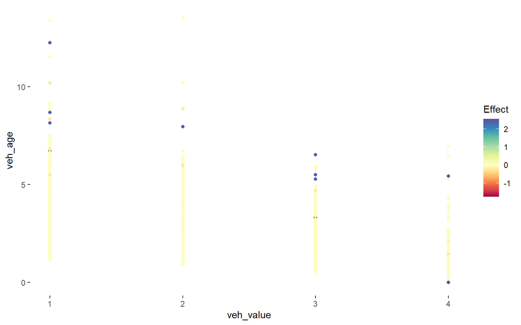

```r
plot_inter_effect(xgb_expl, "veh_age", "veh_value")
```